# Homework assignment

Data Science 1: Machine Learning Concepts

Viktória Mészáros

22/02/2021

# 1. Supervised learning with penalized models and PCA

In this exercise I am analyze a dataset about property values in Manhattan. This dataset is borrowed from the book [“R for Everyone”](https://www.jaredlander.com/r-for-everyone/data-in-r-for-everyone/) by Jared Lander. The goal will be to predict the logarithm of the property value: logTotalValue.

### a) Do a short exploration of data and find possible predictors of the target variable.

I started the exploration of the data by checking missing values. In the original data there were missing values only for the CommFAR variable (504) which is insignificant compared to the number of observations we have, so I deleted there from the data. There was a tricky variable namely ZoneDist where there were actually a lot of missing values but these were not NA but “Missing”. I checked what percentage of the observation are missing for each ZoneDist variable. As more than 99.9% were Missing for ZoneDist3 and ZoneDist4 I decided the delete these. (These were close to zero variance features, so they would not improvee the models).

```
## CommFAR
##     504
```

```
## [1] 92.88729
```

```
## [1] 99.9307
```

```
## [1] 99.99685
```

For unique values I created a table to understand how many different values each feature has and if they are in the righ format (Factor, numeric, etc.). I found 3 variables which were numeric but actually they should have been factor (Council, PolicePrct, HealtArea), so I change the type of those. I also changed Yes-No values to 0-1s.

| columns | unique_values | class |
| --- | --- | --- |
| TotalValue | 18552 | numeric |
| SchoolDistrict | 7 | factor |
| Council | 10 | integer |
| FireService | 3 | factor |
| PolicePrct | 24 | integer |
| HealthArea | 85 | integer |
| ZoneDist1 | 5 | factor |
| ZoneDist2 | 5 | factor |
| Class | 25 | factor |
| LandUse | 11 | factor |
| Easements | 4 | integer |
| OwnerType | 5 | factor |
| LotArea | 7497 | integer |
| BldgArea | 15075 | integer |
| ComArea | 6959 | integer |
| ResArea | 12187 | integer |
| OfficeArea | 2576 | integer |
| RetailArea | 3651 | integer |
| GarageArea | 510 | integer |
| StrgeArea | 842 | integer |
| FactryArea | 118 | integer |
| OtherArea | 2065 | integer |
| NumBldgs | 19 | integer |
| NumFloors | 74 | numeric |
| UnitsRes | 295 | integer |
| UnitsTotal | 307 | integer |
| LotFront | 2490 | numeric |
| LotDepth | 2177 | numeric |
| BldgFront | 1162 | numeric |
| BldgDepth | 981 | numeric |
| Extension | 4 | factor |
| Proximity | 4 | factor |
| IrregularLot | 2 | factor |
| LotType | 10 | factor |
| BasementType | 6 | factor |
| Landmark | 2 | factor |
| BuiltFAR | 1595 | numeric |
| ResidFAR | 15 | numeric |
| CommFAR | 11 | numeric |
| FacilFAR | 19 | numeric |
| Built | 10 | factor |
| HistoricDistrict | 2 | factor |
| High | 2 | logical |
| logTotalValue | 18552 | numeric |

#### Target variable

I already know I had to find the logToltaValue, but I wanted to have a look at the distribution and why we decided to take the log. It is really nicely showed from the data that the original value had a skewed distribution with a long right tail, so it made sense to make a logarithmic transformation as with that the distribution is more like normal.

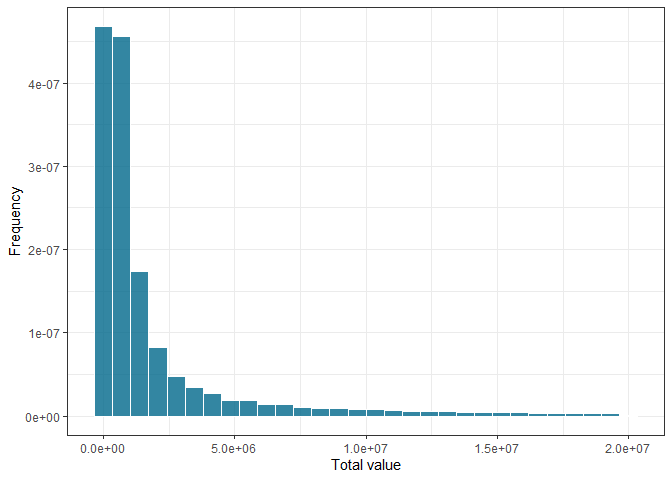

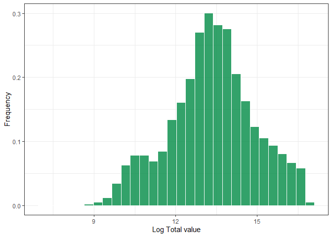

#### Numeric variables

I looked at the distributions for all numberic variables. You can see that most of them is skewed witha a long right tail. I decided to do winzoring on my data. For all the columns that looked skewed I changed the 3 higest extreme values to the 4th highest value. I did not want to make a lot of changes, as the hihger values could have important meaning as well, so I decicded on this top 3 replacement as it is only excluding the highly extreme values that could alter the models a lot.

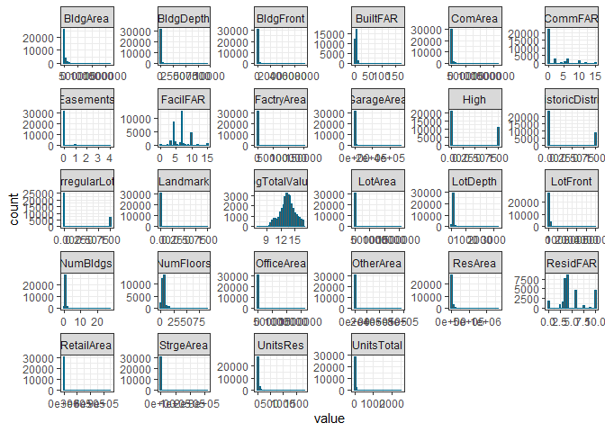

#### Correlation

I looked at correlations as well, first with a correlation matrix, from which I managed to get a deeper understanding of the interactions between variables, and more importantly o which features have the highest correlation with my Target variable

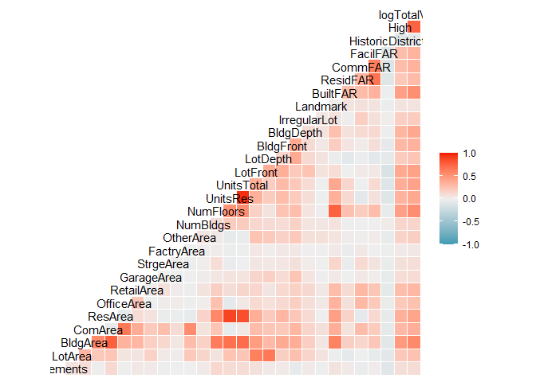

The most important features that correlates most with logTotalValue are BldgArea, NumFloors, LotFront, BuiltFARand High. For these I created the paired graphs to see how the logTotalValue depends on them.

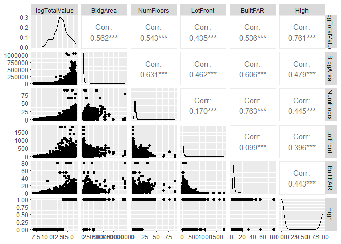

### b) Creating training and test set

Before building any models I separated the data into training and test sets. I put 30% of the observations totally randomly to a train test, while the remaining 70% became part of the test set. I will use the traning set tobuild all my models and only use the test set to evaluate them on “new data”.

```r
set.seed(2021)

training_ratio <- 0.3

train_indices <- createDataPartition(
  y = data[["logTotalValue"]],
  times = 1,
  p = training_ratio,
  list = FALSE
) %>% as.vector()
data_train <- data[train_indices, ]
data_test <- data[-train_indices, ]
```

### c) Use a linear regression to predict logTotalValue

I created a basic linear regression model to predict the logTotalValue. This will serve as a benchmark model for later on, so I can check if other models can improve the performance of this one. I used 10-fold cross validation to assess predictive power and averaged the RMSE and R squared on the folds. This is also good as this way we get more robust results and the model is less sensitive to sample specific issues.

The R squared is 0.83 which means that our model is capturing 83% on the variation in the outcome variable, logTotalValue and the remaining 17% is left to other factors. The RMSE is 0.65 in the training set and 0.68 in the test set. This higher value is normal. It could mean that we overfit the test set, but in this case this is not the case. The values are really close. It is also important to mention that the train set is only 30% of the data and the test is 70% so there may be patterns that are not represented in the train set, but are in the test data. (I would probably try to use 70-80% od the data as training and look if this changes.)

| linear_R2 | linear_RMSE | linear_test_RMSE |
| --- | --- | --- |
| 0.8302457 | 0.6502333 | 0.6833851 |

### d.) Use penalized linear models for the same task

After I built the baseline simple linear model I used different penalized models. These put a penalty on the sum of regression coefficients either in absolute or squared terms. This will lead to finding less complex models and also solve the problem of correlating features.

- I used the **caret** package *

#### Ridge model

Ridge model puts a penalty on the sum of squared residuals. I checked several lambda values between 0.01 and 0.7 to find the best, which leads to the lowest cross validated RMSE. Lambda is the weight of the penalty term. The higher it is the simpler the model will get. In this case it was 0.11.

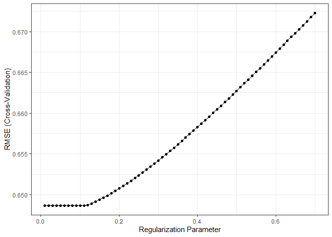

#### LASSO model

Lasso model uses an other type of penalty. It puts a penalty on the sum of the absolute values of coefficients. This also leads to that some coefficients are set exactly to zero, others are only shrunk towards zero. So with lasso we may decrease the number of features more and more as the lambda parameter increases. Here the best lambda was around 0.003. This is really small, meaning we don’t exclude a lot of variables.

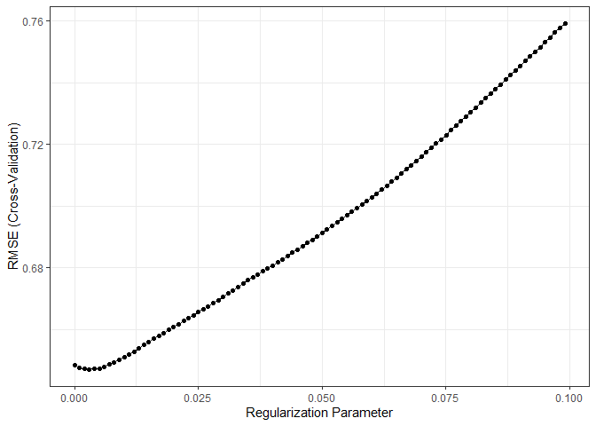

#### Elastic net

With elastic net we can combine the power of a ridge and a lasso model. So we can simultaneously shrink coefficients towards zero with ridge and perform principled variable selection with lasso. To find the best “mixture” of these I will use different alphas between 0 and 1. The optimal alpha is 0.3 and the optimal lambda is 0.0101 for the elastic net. This means we will use a combination of 30% lasso model and 70% ridge.

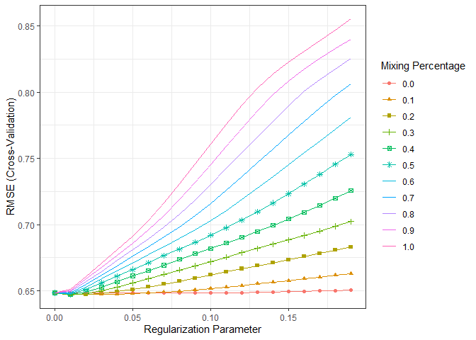

#### Summary

To compare our models we will look at RMSE for them. They are really close to each other, but the best is for the Lasso model.

|  | CV RMSE |
| --- | --- |
| Linear | 0.6502333 |
| Ridge | 0.6487045 |
| Lasso | 0.6471090 |
| Elastic Net | 0.6471202 |

### e) Simplest model that is still good enough

In case we want to look at the simplest but still good models we have to include **selectionFunction = “oneSE”** to the train control in the caret train module. This will look at the highest lambda value which contains the optimal lambda’s error within one standard deviation. This will lead to a simpler model meaning smaller coefficient for ridge and less features in the model for LASSO. For elastic net both of these are true.

```
##
## Call:
## summary.resamples(object = summary_2)
##
## Models: Linear, RIDGE, LASSO, Elastic Net, RIDGE_1se, LASSO_1se, Elastic_Net_1se
## Number of resamples: 10
##
## MAE
##                      Min.   1st Qu.    Median      Mean   3rd Qu.      Max.
## Linear          0.4573696 0.4736430 0.4882097 0.4857385 0.4986513 0.5177961
## RIDGE           0.4585929 0.4737631 0.4857655 0.4846414 0.4951195 0.5138698
## LASSO           0.4548794 0.4763237 0.4870338 0.4848349 0.4966869 0.5136231
## Elastic Net     0.4547117 0.4762412 0.4868570 0.4846552 0.4966120 0.5130691
## RIDGE_1se       0.4698426 0.4812901 0.4935129 0.4921107 0.5003920 0.5196595
## LASSO_1se       0.4695590 0.4884624 0.4966439 0.4964520 0.5102339 0.5203059
## Elastic_Net_1se 0.4603371 0.4745705 0.4867004 0.4856057 0.4950853 0.5143022
##                 NA's
## Linear             0
## RIDGE              0
## LASSO              0
## Elastic Net        0
## RIDGE_1se          0
## LASSO_1se          0
## Elastic_Net_1se    0
##
## RMSE
##                      Min.   1st Qu.    Median      Mean   3rd Qu.      Max.
## Linear          0.5889049 0.6230790 0.6541921 0.6502333 0.6742225 0.6985001
## RIDGE           0.5873271 0.6220189 0.6551891 0.6487045 0.6694897 0.6944763
## LASSO           0.5813830 0.6186138 0.6516893 0.6471090 0.6712688 0.6948642
## Elastic Net     0.5814006 0.6186715 0.6519122 0.6471202 0.6709849 0.6949081
## RIDGE_1se       0.6041249 0.6368792 0.6667613 0.6600356 0.6767567 0.7023154
## LASSO_1se       0.5969269 0.6314115 0.6659511 0.6588477 0.6807042 0.7089016
## Elastic_Net_1se 0.5906788 0.6246441 0.6572797 0.6504737 0.6700859 0.6951515
##                 NA's
## Linear             0
## RIDGE              0
## LASSO              0
## Elastic Net        0
## RIDGE_1se          0
## LASSO_1se          0
## Elastic_Net_1se    0
##
## Rsquared
##                      Min.   1st Qu.    Median      Mean   3rd Qu.      Max.
## Linear          0.8102730 0.8221199 0.8326708 0.8302457 0.8338430 0.8559268
## RIDGE           0.8133424 0.8224472 0.8313689 0.8310392 0.8364576 0.8572193
## LASSO           0.8136483 0.8237199 0.8330116 0.8317848 0.8357643 0.8597037
## Elastic Net     0.8138454 0.8237941 0.8330524 0.8317788 0.8356624 0.8597209
## RIDGE_1se       0.8117832 0.8172808 0.8256080 0.8269850 0.8328600 0.8516571
## LASSO_1se       0.8070887 0.8186577 0.8259152 0.8262892 0.8313664 0.8531193
## Elastic_Net_1se 0.8137402 0.8213540 0.8302467 0.8303651 0.8361541 0.8560212
##                 NA's
## Linear             0
## RIDGE              0
## LASSO              0
## Elastic Net        0
## RIDGE_1se          0
## LASSO_1se          0
## Elastic_Net_1se    0
```

#### Summary

We can see that based on RMSE values looking at the simplest models increase a bit, while R squared decreases.

### f) Using PCA for dimensionality reduction

After looking at penalized models lets do PCA. I checked a simple PCA models with tune grid 1:100 to make sure that the high number of factor variables are took into consideration. 27 components capture already 99.9% of the variance, while 28 captures 99.99%. The optimal number in the end was 97.

```
## Created from 31746 samples and 43 variables
##
## Pre-processing:
##   - centered (28)
##   - ignored (15)
##   - principal component signal extraction (28)
##   - scaled (28)
##
## PCA needed 27 components to capture 99.9 percent of the variance
```

```
## Created from 31746 samples and 43 variables
##
## Pre-processing:
##   - centered (28)
##   - ignored (15)
##   - principal component signal extraction (28)
##   - scaled (28)
##
## PCA needed 28 components to capture 100 percent of the variance
```

```
## Principal Component Analysis
##
## 31746 samples
##    42 predictor
##
## Pre-processing: centered (226), scaled (226)
## Resampling: Cross-Validated (10 fold)
## Summary of sample sizes: 28571, 28572, 28572, 28571, 28572, 28571, ...
## Resampling results across tuning parameters:
##
##   ncomp  RMSE       Rsquared   MAE
##     1    0.9194865  0.6580203  0.7038338
##     2    0.9152098  0.6611252  0.7069646
##     3    0.9142903  0.6618186  0.7049430
##     4    0.8916434  0.6783821  0.6848197
```

[output cut: 99 more lines]

### g) Apply PCA prior to estimating penalized models

To apply PCA I needed to put is to preProcess and to trConrol. For train control I chose a thresh so PCA will cover 99% of variation.

```
##
## Call:
## summary.resamples(object = summary_3)
##
## Models: Linear, RIDGE, LASSO, Elastic Net, RIDGE_1se, LASSO_1se, Elastic_Net_1se, RIDGE_pca, LASSO_pca, Elastic_Net_pca
## Number of resamples: 10
##
## MAE
##                      Min.   1st Qu.    Median      Mean   3rd Qu.      Max.
## Linear          0.4573696 0.4736430 0.4882097 0.4857385 0.4986513 0.5177961
## RIDGE           0.4585929 0.4737631 0.4857655 0.4846414 0.4951195 0.5138698
## LASSO           0.4548794 0.4763237 0.4870338 0.4848349 0.4966869 0.5136231
## Elastic Net     0.4547117 0.4762412 0.4868570 0.4846552 0.4966120 0.5130691
## RIDGE_1se       0.4698426 0.4812901 0.4935129 0.4921107 0.5003920 0.5196595
## LASSO_1se       0.4695590 0.4884624 0.4966439 0.4964520 0.5102339 0.5203059
## Elastic_Net_1se 0.4603371 0.4745705 0.4867004 0.4856057 0.4950853 0.5143022
## RIDGE_pca       0.4750861 0.4962910 0.5055934 0.5048270 0.5176781 0.5335826
## LASSO_pca       0.4694304 0.4919644 0.5031512 0.5014885 0.5160423 0.5232327
## Elastic_Net_pca 0.4694386 0.4919498 0.5031072 0.5014490 0.5159775 0.5232530
##                 NA's
## Linear             0
## RIDGE              0
## LASSO              0
## Elastic Net        0
## RIDGE_1se          0
## LASSO_1se          0
## Elastic_Net_1se    0
## RIDGE_pca          0
## LASSO_pca          0
## Elastic_Net_pca    0
##
## RMSE
##                      Min.   1st Qu.    Median      Mean   3rd Qu.      Max.
## Linear          0.5889049 0.6230790 0.6541921 0.6502333 0.6742225 0.6985001
## RIDGE           0.5873271 0.6220189 0.6551891 0.6487045 0.6694897 0.6944763
## LASSO           0.5813830 0.6186138 0.6516893 0.6471090 0.6712688 0.6948642
## Elastic Net     0.5814006 0.6186715 0.6519122 0.6471202 0.6709849 0.6949081
## RIDGE_1se       0.6041249 0.6368792 0.6667613 0.6600356 0.6767567 0.7023154
## LASSO_1se       0.5969269 0.6314115 0.6659511 0.6588477 0.6807042 0.7089016
## Elastic_Net_1se 0.5906788 0.6246441 0.6572797 0.6504737 0.6700859 0.6951515
```

[output cut: 23 more lines]

```
## Elastic_Net_1se 0.8137402 0.8213540 0.8302467 0.8303651 0.8361541 0.8560212
## RIDGE_pca       0.7980605 0.8109201 0.8194365 0.8214295 0.8309091 0.8515841
## LASSO_pca       0.7981925 0.8111260 0.8197291 0.8214467 0.8307063 0.8513883
## Elastic_Net_pca 0.7981925 0.8111361 0.8197291 0.8214507 0.8307063 0.8513883
##                 NA's
## Linear             0
## RIDGE              0
## LASSO              0
## Elastic Net        0
## RIDGE_1se          0
## LASSO_1se          0
## Elastic_Net_1se    0
## RIDGE_pca          0
## LASSO_pca          0
## Elastic_Net_pca    0
```

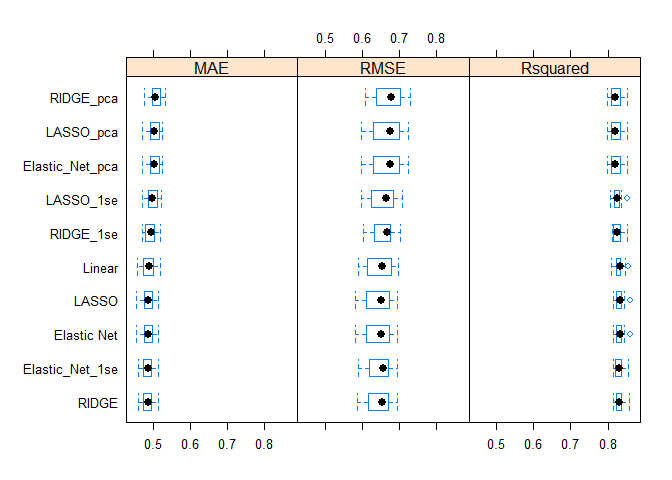

### h) Select the best model

We looked at the rmse values again. There are no significant differences, but the best model is the lasso based on the smallest RMSE and the largest R squared. Based on this I will use the lasso as the final model. I evaluate my best model by looking at RMSE value in the test set. In this case it is 0.68.

```
##
## Call:
## summary.diff.resamples(object = model_differences)
##
## p-value adjustment: bonferroni
## Upper diagonal: estimates of the difference
## Lower diagonal: p-value for H0: difference = 0
##
## MAE
##                 Linear    RIDGE      LASSO      Elastic Net RIDGE_1se
## Linear                     1.097e-03  9.036e-04  1.083e-03  -6.372e-03
## RIDGE           1.0000000            -1.935e-04 -1.372e-05  -7.469e-03
## LASSO           1.0000000 1.0000000              1.798e-04  -7.276e-03
## Elastic Net     1.0000000 1.0000000  0.4179935              -7.456e-03
## RIDGE_1se       0.2771340 0.0064940  0.1918339  0.1577967
## LASSO_1se       0.0212871 0.0050555  0.0005010  0.0003765   1.0000000
## Elastic_Net_1se 1.0000000 0.3602792  1.0000000  1.0000000   0.0025029
## RIDGE_pca       0.0003367 9.534e-05  7.818e-06  6.735e-06   0.0189274
## LASSO_pca       0.0024161 0.0009194  7.108e-05  5.649e-05   0.3198503
## Elastic_Net_pca 0.0024137 0.0009105  6.962e-05  5.526e-05   0.3215604
##                 LASSO_1se  Elastic_Net_1se RIDGE_pca  LASSO_pca
## Linear          -1.071e-02  1.328e-04      -1.909e-02 -1.575e-02
## RIDGE           -1.181e-02 -9.643e-04      -2.019e-02 -1.685e-02
## LASSO           -1.162e-02 -7.708e-04      -1.999e-02 -1.665e-02
## Elastic Net     -1.180e-02 -9.505e-04      -2.017e-02 -1.683e-02
## RIDGE_1se       -4.341e-03  6.505e-03      -1.272e-02 -9.378e-03
## LASSO_1se                   1.085e-02      -8.375e-03 -5.037e-03
## Elastic_Net_1se 0.0127822                  -1.922e-02 -1.588e-02
## RIDGE_pca       0.0001973  0.0001947                   3.338e-03
## LASSO_pca       0.0489927  0.0021990       0.8124715
## Elastic_Net_pca 0.0481581  0.0021808       0.7292081  0.7167909
##                 Elastic_Net_pca
## Linear          -1.571e-02
## RIDGE           -1.681e-02
## LASSO           -1.661e-02
## Elastic Net     -1.679e-02
## RIDGE_1se       -9.338e-03
## LASSO_1se       -4.997e-03
## Elastic_Net_1se -1.584e-02
## RIDGE_pca        3.378e-03
```

[output cut: 57 more lines]

```
## Elastic_Net_1se 0.119016                    8.936e-03  8.918e-03
## RIDGE_pca       0.066755   0.009120                   -1.717e-05
## LASSO_pca       0.051309   0.006533        1.000000
## Elastic_Net_pca 0.051502   0.006595        1.000000   1.000000
##                 Elastic_Net_pca
## Linear           8.795e-03
## RIDGE            9.588e-03
## LASSO            1.033e-02
## Elastic Net      1.033e-02
## RIDGE_1se        5.534e-03
## LASSO_1se        4.838e-03
## Elastic_Net_1se  8.914e-03
## RIDGE_pca       -2.120e-05
## LASSO_pca       -4.031e-06
## Elastic_Net_pca
```

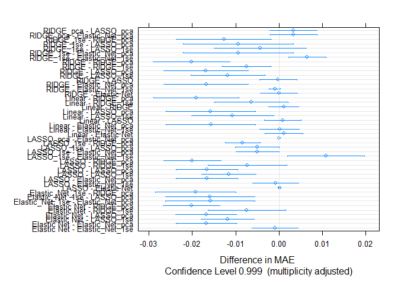

```
## [1] 0.6820417
```

## 2. Clustering on the USArrests dataset

In this exercise I will use the USAArrests data set. I will apply clustering then make sense of the clusters using the principal components.

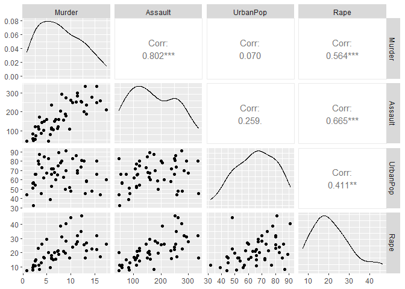

### b) Determine the optimal number of clusters

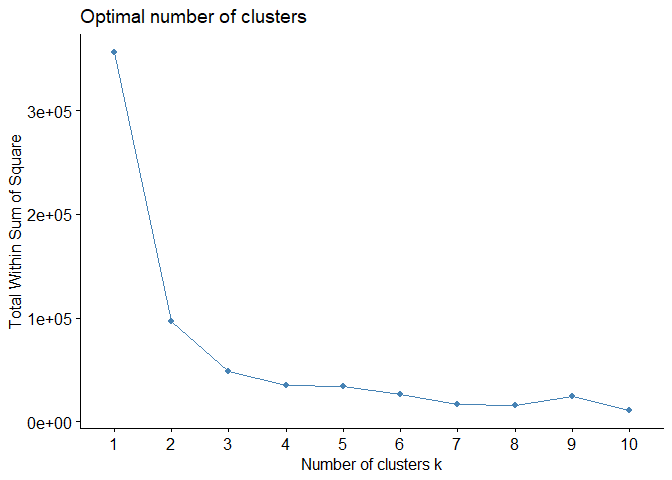

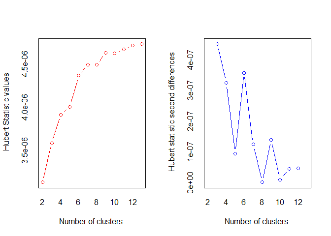

```
## *** : The Hubert index is a graphical method of determining the number of clusters.
##                 In the plot of Hubert index, we seek a significant knee that corresponds to a
##                 significant increase of the value of the measure i.e the significant peak in Hubert
##                 index second differences plot.
##
```

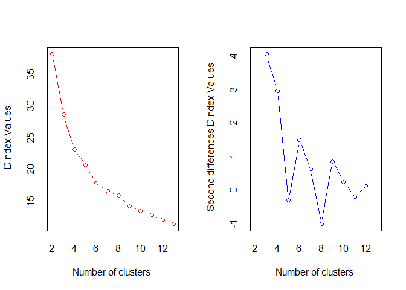

```
## *** : The D index is a graphical method of determining the number of clusters.
##                 In the plot of D index, we seek a significant knee (the significant peak in Dindex
##                 second differences plot) that corresponds to a significant increase of the value of
##                 the measure.
##
## * Among all indices:
## * 9 proposed 2 as the best number of clusters
## * 5 proposed 3 as the best number of clusters
## * 1 proposed 4 as the best number of clusters
## * 1 proposed 5 as the best number of clusters
## * 4 proposed 6 as the best number of clusters
## * 3 proposed 9 as the best number of clusters
## * 1 proposed 13 as the best number of clusters
##
##                    ***** Conclusion *****
##
## * According to the majority rule, the best number of clusters is  2
##
##
```

[output not shown]

[output cut: 36 more lines]

```
##              2              2              1              2              2
##         Kansas       Kentucky      Louisiana          Maine       Maryland
##              2              2              1              2              1
##  Massachusetts       Michigan      Minnesota    Mississippi       Missouri
##              2              1              2              1              2
##        Montana       Nebraska         Nevada  New Hampshire     New Jersey
##              2              2              1              2              2
##     New Mexico       New York North Carolina   North Dakota           Ohio
##              1              1              1              2              2
##       Oklahoma         Oregon   Pennsylvania   Rhode Island South Carolina
##              2              2              2              2              1
##   South Dakota      Tennessee          Texas           Utah        Vermont
##              2              1              1              2              2
##       Virginia     Washington  West Virginia      Wisconsin        Wyoming
##              2              2              2              2              2
```

### c) Use the k-means method to cluster states

```
## K-means clustering with 2 clusters of sizes 21, 29
##
## Cluster means:
##      Murder  Assault UrbanPop     Rape
## 1 11.857143 255.0000 67.61905 28.11429
## 2  4.841379 109.7586 64.03448 16.24828
##
## Clustering vector:
##        Alabama         Alaska        Arizona       Arkansas     California
##              1              1              1              1              1
##       Colorado    Connecticut       Delaware        Florida        Georgia
##              1              2              1              1              1
##         Hawaii          Idaho       Illinois        Indiana           Iowa
##              2              2              1              2              2
##         Kansas       Kentucky      Louisiana          Maine       Maryland
##              2              2              1              2              1
##  Massachusetts       Michigan      Minnesota    Mississippi       Missouri
##              2              1              2              1              2
##        Montana       Nebraska         Nevada  New Hampshire     New Jersey
##              2              2              1              2              2
##     New Mexico       New York North Carolina   North Dakota           Ohio
##              1              1              1              2              2
##       Oklahoma         Oregon   Pennsylvania   Rhode Island South Carolina
##              2              2              2              2              1
##   South Dakota      Tennessee          Texas           Utah        Vermont
##              2              1              1              2              2
##       Virginia     Washington  West Virginia      Wisconsin        Wyoming
##              2              2              2              2              2
##
## Within cluster sum of squares by cluster:
## [1] 41636.73 54762.30
##  (between_SS / total_SS =  72.9 %)
##
## Available components:
##
## [1] "cluster"      "centers"      "totss"        "withinss"     "tot.withinss"
## [6] "betweenss"    "size"         "iter"         "ifault"
```

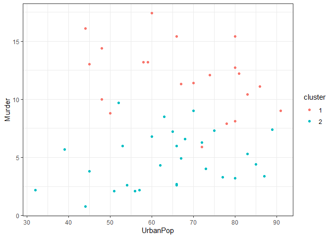

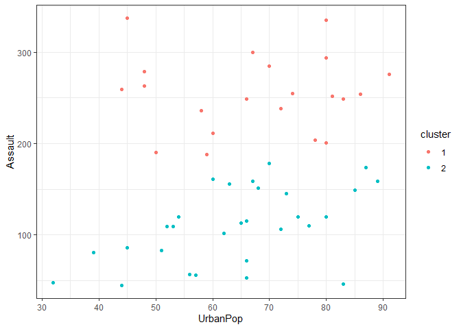

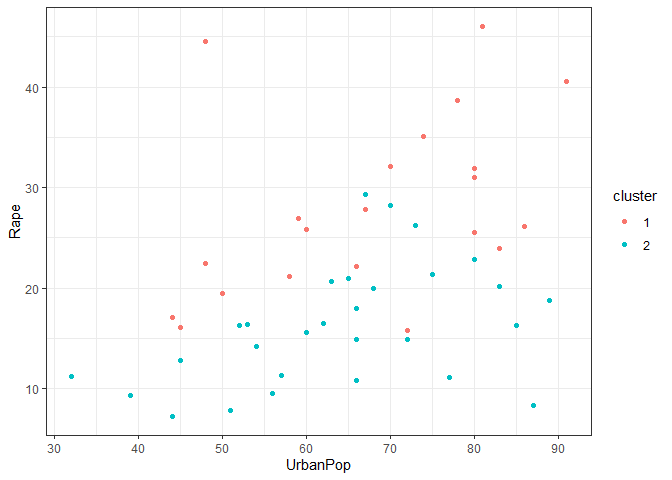

### d) Perform PCA and get the first two principal component coordinates for all observations

I got the first two principal component. Here I used scaling.

```r
pca_result <- prcomp(df, scale = TRUE)
first_two_pc <- as_tibble(pca_result$x[, 1:2])
```

### e) Plot clusters in the coordinate system defined by the first two principal components

It is really nicely visible that clusters are separate on the graph. It can be also seen that the first PCA really separates the clusters.

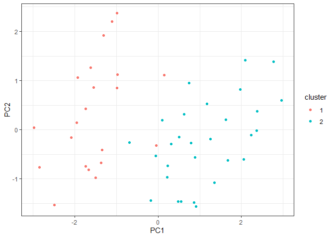

# 3. PCA of high-dimensional data

In the last exercise I will perform PCA on 40 observations of 1000 variables. For this I will use data about genes of tissues of healthy and diseased patients.

### a) Perform PCA on this data with scaling features

I centered and scaled the features and then preformed a PCA. Out of the 1000 features 39 components are already covering 99.9% of the varience. We learned that we have the same amount of PCAs as the number of variables. After thinking it through I would say in this case it is not 100% true. As we have only 40 observations they cannot create more than 39 dimensions so there is no sense in looking at more component than 39. (Think of 3 observations and 10 features. Even though theoretically we can calculate 10 PCAs three dots can only determine 2 dimensions.)

```
## Created from 40 samples and 1000 variables
##
## Pre-processing:
##   - centered (1000)
##   - ignored (0)
##   - principal component signal extraction (1000)
##   - scaled (1000)
##
## PCA needed 39 components to capture 99.9 percent of the variance
```

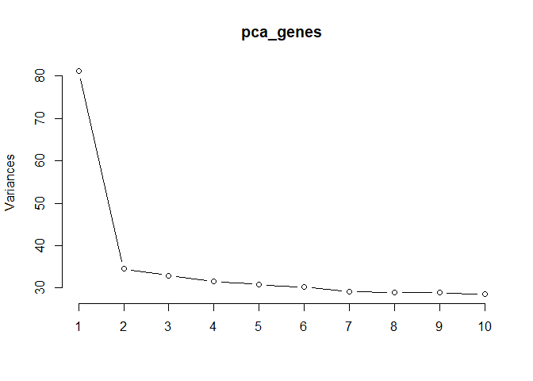

### b) Visualize data points in the space of the first two principal components

There are two significant categories seen on this graph. PCA1 can devide the observations to two separate categories quite nicely. And is doues it perfectly look that the pationts from 1 to 20 are in one category while from 21 to 40 are in another.

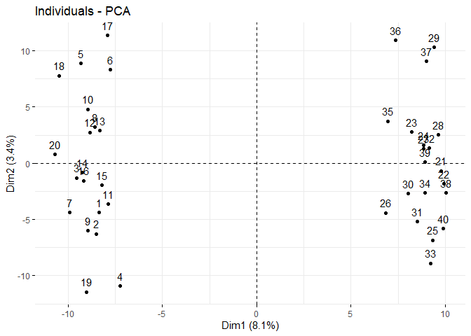

### c) Which individual features can matter

With this calculation I check what features matter the most for PCA1 as it is created as the linear combination of variables it can be seen what variables have to most effect in the combination. For this we need to check the largest coordinates in absolute terms. The two features that matter the most are V502 and V589. We can do one-by-one plot to see how the points relate. We can see that these two features already determine a linear pattern in the data. These two variables are positively correlated.

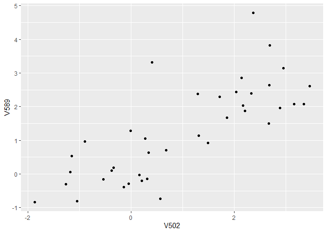

```r
tdf <- data.frame(pca_genes$rotation)

ordered <- tdf %>%
  arrange(-abs(tdf$PC1))


ggplot(genes, aes(x = V502, y = V589)) +
  geom_point()
```

PCA thus offers a way to summarize vast amounts of variables in a handful of dimensions. This can serve as a tool to pick interesting variables where, for example, visual inspection would be hopeless